# Reproducible Research: Peer Assessment 1

Bruce Huang

Friday, February 13, 2015

## Load Library

```r
library(ggplot2)
library(plyr)
library(lubridate)
library(lattice)
library(knitr)
```

## Loading and preprocessing the data

1. Load the data
2. Process/transform the data (if necessary) into a format suitable for your analysis

```r
nike_data <- read.csv( "activity.csv", sep=",", na.strings = "NA",
                       colClasses =c("numeric","Date","numeric"))
```

## What is mean total number of steps taken per day?

1. Calculate the total number of steps taken per day

```r
Daily_Step <- tapply(nike_data$steps,nike_data$date,function(x) sum(x,na.rm=TRUE))
summary(Daily_Step)
```

```
##    Min. 1st Qu.  Median    Mean 3rd Qu.    Max.
##       0    6778   10400    9354   12810   21190
```

2. Make a histogram of the total number of steps taken each day

```
## stat_bin: binwidth defaulted to range/30. Use 'binwidth = x' to adjust this.
```

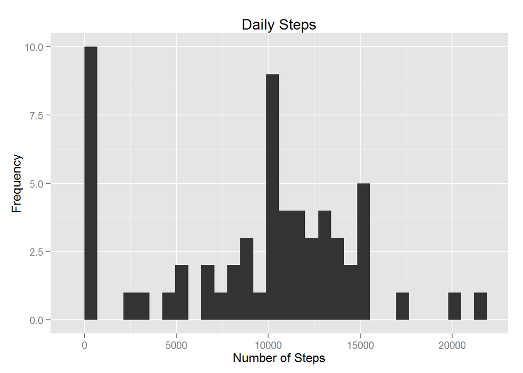

```r
qplot(Daily_Step, xlab='Number of Steps', ylab='Frequency', main="Daily Steps")
```

3. Calculate and report the mean and median of the total number of steps taken per day

```r
mean(Daily_Step)
```

```
## [1] 9354.23
```

```r
median(Daily_Step)
```

```
## [1] 10395
```

## What is the average daily activity pattern?

1. Make a time series plot of the 5-minute interval (x-axis) and the average number of steps taken, averaged across all days (y-axis)

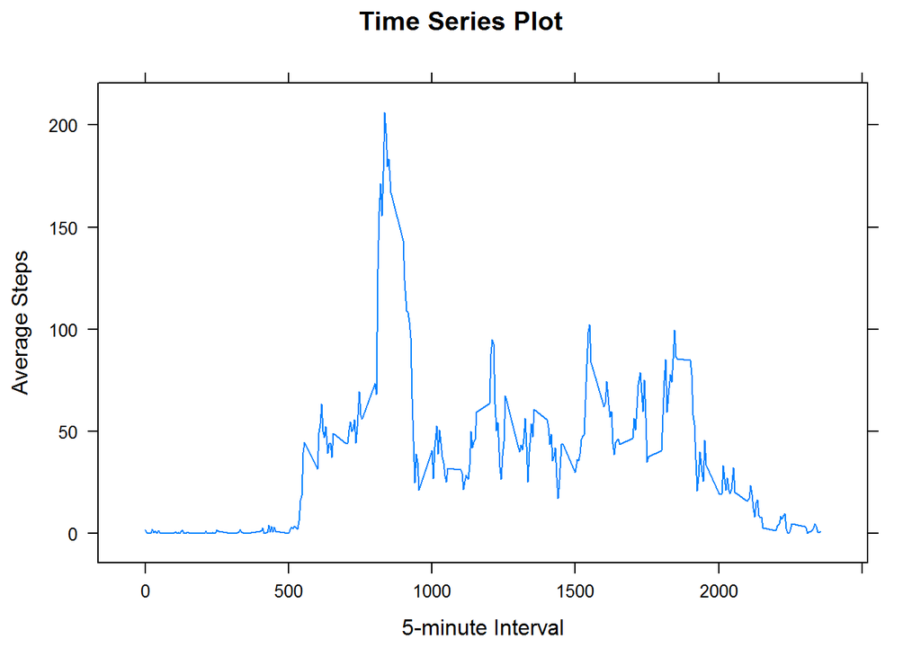

```r
avg_pattern <- aggregate(nike_data$steps ~ nike_data$interval
                     , nike_data, FUN=mean, na.rm=T)

names(avg_pattern) <- c("interval","avg_steps")

xyplot(avg_pattern$avg_steps ~ avg_pattern$interval,
       type = "l", ylab = "Average Steps",
       xlab ="5-minute Interval",
       main = "Time Series Plot")
```

2. Which 5-minute interval, on average across all the days in the dataset, contains the maximum number of steps?

```r
which.max(avg_pattern$avg_steps)
```

```
## [1] 104
```

## Imputing missing values

1. Calculate and report the total number of missing values in the dataset.

```r
sum(is.na(nike_data$steps))
```

```
## [1] 2304
```

2. Devise a strategy for filling in all of the missing values in the dataset.

```r
missing <- nike_data[is.na(nike_data),]
missing$steps <- merge(avg_pattern, missing)$avg_steps
```

3. Create a new dataset that is equal to the original dataset but with the missing data filled in.

```r
nike_data1 <- nike_data
nike_data1[is.na(nike_data),] <- missing
Daily_Step1 <- tapply(nike_data1$steps,nike_data1$date,function(x) sum(x,na.rm=TRUE))
```

4. Make a histogram of the total number of steps taken each day and Calculate and report the mean and median total number of steps taken per day.

```
## stat_bin: binwidth defaulted to range/30. Use 'binwidth = x' to adjust this.
```

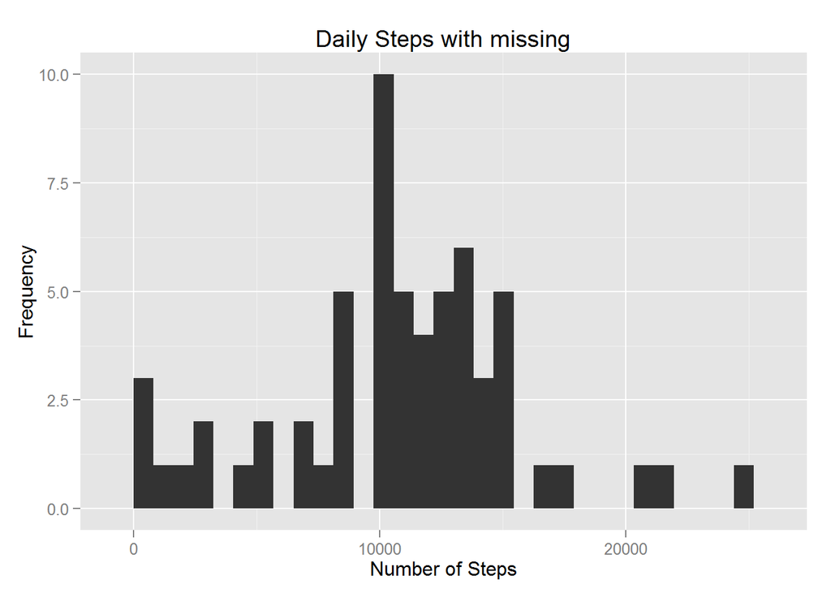

```r
qplot(Daily_Step1, xlab='Number of Steps', ylab='Frequency', main="Daily Steps with missing")
```

```r
mean(Daily_Step1)
```

```
## [1] 10766.19
```

```r
median(Daily_Step1)
```

```
## [1] 11015
```

## Are there differences in activity patterns between weekdays and weekends?

1. Create a new factor variable in the dataset with two levels – “weekday” and “weekend” indicating whether a given date is a weekday or weekend day.

```r
Weekday_type <- function(date) {
   if (weekdays(as.Date(date)) %in% c("Saturday", "Sunday")) {"Weekend"
        } else {"Weekday"
        }
}
nike_data1$Weekday_type <- as.factor(sapply(nike_data1$date, Weekday_type))
nike_data1$day <- sapply(nike_data1$date, FUN = Weekday_type)
```

[figure not shown]

```r
avg_pattern2 <- aggregate(steps ~ interval + day, data = nike_data1, mean)
ggplot(avg_pattern2, aes(interval, steps)) + geom_line() + facet_grid(day ~ .) +
    xlab("5-minute interval") + ylab("Number of steps")
```